# Python Intro

[Python Cheatsheet von Prof. Roger Wattenhofer](https://disco.ethz.ch/courses/hs24/coti/lecturenotes/pythoncheatsheet.pdf)

[scientific-python.org](https://scientific-python.org/)

[Not so Short Introduction to Python, Numpy, Matplotlib, etc.](https://moodle-app2.let.ethz.ch/mod/resource/view.php?id=1415279)

## Hello World

**Java**

```
public class Main {
    public static void main(String[] args) {
        System.out.println("Hello World");
    }
}
```

**Python**

```
print("Hello World")
```

Die wichtigsten Unterschiede auf einen Blick:

| Java | Python |
| --- | --- |
| Anweisungen enden mit `;` | Kein Semikolon, eine Anweisung pro Zeile |
| Blöcke mit `{ }` | Blöcke durch **Einrückung** (4 Leerzeichen) |
| Kommentare `//` und `/* */` | Kommentare `#`, Dokumentation `"""Doc"""` |
| Kompilieren, dann ausführen | Wird direkt interpretiert |
| `System.out.println(...)` | `print(...)` |

```python
print("Hello World")
print("Mehrere", "Argumente", ".")
```

```
Hello World
Mehrere Argumente .
```

### Einrückung

In Java ist Einrückung Stil. Blöcke werden mit geschweiften Klammern gemacht. In Python **definiert** die Einrückung den Block.

```python
x = 2

if x > 3:
    print("Hello")

print("World")
```

```
World
```

## Variablen und Datentypen

Die wichtigsten Typen:

- `int`
- `float` (entspricht `double`)
- `str`
- `bool`
- `NoneType`
- Es gibt kein `long`, `short` oder `byte`
- `int` ist beliebig gross, kein Overflow.

| Java | Python |
| --- | --- |
| Statisch typisiert: Der Typ wird deklariert und kann sich nicht ändern. | Dynamisch typisiert: Der Typ hängt am Wert. |
| `int zahl = 42;` | `zahl = 42` |
| `double pi = 3.14159;` | `pi = 3.14159` |
| `String name = "Ada";` | `name = "Ada"` |
| `boolean aktiv = true;` | `aktiv = True` |
| `char c = 'x';` | `c = "x"` |
| `final int MAX = 100;` | `MAX = 100 # Konvention` |
| `Object nichts = null;` | `nichts = None` |

```python
zahl = 42
print(zahl, type(zahl))

zahl = 2.2
print(zahl, type(zahl))
```

```
42 <class 'int'>
2.2 <class 'float'>
```

```python
zahl = "Text"
print(zahl, type(zahl))
```

```
Text <class 'str'>
```

Overflow?

```python
grosse_zahl = 2 ** 500
print(grosse_zahl)
```

```
3273390607896141870013189696827599152216642046043064789483291368096133796404674554883270092325904157150886684127560071009217256545885393053328527589376
```

Swap

```python
a = 1
b = 2
a, b = b, a

print(a, b)
```

```
2 1
```

### Typumwandlung

```python
print(int("42") + 1)
print(int("42") + 1.0)
print(float("3.5") + 2)
```

```
43
43.0
5.5
```

```python
print(int(3.9))
print(round(3.9))
print(bool(0), bool(""), bool([]), bool("y"))
```

```
3
4
False False False True
```

```python
print(str(42) + "1")
# print("5" + 3)   # TypeError: kein implizites Casting von int zu str
```

```
421
```

## Operatoren

| Java | Python | Bemerkung |
| --- | --- | --- |
| `7 / 2.0` → `3.5` | `7 / 2` → `3.5` | `/` liefert in Python **immer** einen `float` |
| `7 / 2` → `3` | `7 // 2` → `3` | Ganzzahldivision (rundet immer ab, auch bei negativen Zahlen) |
| `7 % 2` → `1` | `7 % 2` → `1` | Modulo |
| `Math.pow(2, 10)` | `2 ** 10` | Potenz |
| `i++`, `++i` | – | verwende `i += 1` |
| `a && b`, `a \\|\\| b`, `!a` | `a and b`, `a or b`, `not a` | logische Operatoren sind Wörter |
| `a == b` (bei Objekten: Referenz) | `a == b` (Inhalt), `a is b` (Referenz) | `is` braucht man fast nur für `x is None` |
| `x > 0 && x < 10` | `0 < x < 10` | Vergleiche lassen sich verketten |
| `Math.abs`, `Math.max`, `Math.min` | `abs`, `max`, `min` | eingebaute Funktionen |

```python
print("7 / 2 = ", 7 / 2)
print("7 // 2 = ",7 // 2)
print("-7 // 2 = ",-7 // 2)  # java -3
```

```
7 / 2 =  3.5
7 // 2 =  3
-7 // 2 =  -4
```

```python
print("2 ** 10 = ",2 ** 10)

x = 5
x += 1        # kein x++ in Python
print("x = 5, x += 1 -> x = ",x)
```

```
2 ** 10 =  1024
x = 5, x += 1 -> x =  6
```

```python
print("x > 3 and x < 10 = ", x > 3 and x < 10)
print("3 < x < 10 = ", 3 < x < 10)
```

```
x > 3 and x < 10 =  True
3 < x < 10 =  True
```

```python
a = [1, 2, 3]
b = [1, 2, 3]
print("a == b =", a == b)
print("a is b = ", a is b)
```

```
a == b = True
a is b =  False
```

```python
print("max(4, 9, 2) = ", max(4, 9, 2))
print("min([5, 1, 8]) = ", min([5, 1, 8]))
print("round(3.14159, 2) = ", round(3.14159, 2))
```

```
max(4, 9, 2) =  9
min([5, 1, 8]) =  1
round(3.14159, 2) =  3.14
```

## Kontrollfluss

### If-Else

- `elif` statt `else if`
- ein Doppelpunkt nach der Bedingung
- keine Klammern nötig

```
if x > 0:
    print("positiv")
elif x == 0:
    print("null")
else:
    print("negativ")

s = "ja" if x > 0 else "nein"
```

### Schleifen

**Java**

```
for (int i = 0; i < 5; i++) { ... }
for (String name : names) { ... }
while (bedingung) { ... }
do { ... } while (bedingung);
```

**Python**

```
for i in range(5): ...           # 0, 1, 2, 3, 4
for name in names: ...           # jede for-Schleife ist eine for-each-Schleife
while bedingung: ...
# do-while gibt es nicht → while True: ... if ...: break
```

`range(start, stop, step)` erzeugt die Zahlen von `start` bis `stop`, wobei `stop` selbst nicht mehr dazugehört. `break` und `continue` funktionieren wie in Java.

```python
for i in range(1, 5):
    print(i)
print()
```

```
1
2
3
4
```

Schritt

```python
for i in range(2, 11, 3):
    print(i, end=" ")
print()
```

```
2 5 8
```

```python
namen = ["Ada", "Linus", "Grace"]
for name in namen:
    print(f"Hallo {name}")

# Index UND Element: enumerate statt manueller Zähler
for i, name in enumerate(namen):
    print(i, name)

# Zwei Listen parallel durchlaufen: zip
alter = [36, 54, 85]
for name, a in zip(namen, alter):
    print(f"{name} ist {a} Jahre alt")

# while mit break – das Python-Muster für do-while
n = 0
while True:
    n += 1
    if n >= 3:
        break
print("n =", n)

# Besonderheit: else an einer Schleife läuft, wenn kein break ausgelöst wurde
for zahl in [2, 4, 6]:
    if zahl % 2 == 1:
        print("ungerade Zahl gefunden")
        break
else:
    print("nur gerade Zahlen")
```

```
Hallo Ada
Hallo Linus
Hallo Grace
0 Ada
1 Linus
2 Grace
Ada ist 36 Jahre alt
Linus ist 54 Jahre alt
Grace ist 85 Jahre alt
n = 3
nur gerade Zahlen
```

## Listen

Python bringt die wichtigsten Sammlungen direkt in der Sprache mit – ohne Import, mit eigener Literal-Syntax.

| Java | Python | Literal |
| --- | --- | --- |
| `ArrayList<T>` | `list` | `[1, 2, 3]` |
| `int[]` (Array) | `list` (oder NumPy) | `[1, 2, 3]` |
| – | `tuple` (unveränderliche Liste) | `(1, 2, 3)` |
| `HashMap<K, V>` | `dict` | `{"a": 1, "b": 2}` |
| `HashSet<T>` | `set` | `{1, 2, 3}` |

Python-Listen dürfen gemischte Typen enthalten (`[1, "zwei", 3.0]`) – in der Praxis ist das aber selten sinnvoll.

### Listen (≈ `ArrayList`)

| Java | Python |
| --- | --- |
| `list.add(x)` | `liste.append(x)` |
| `list.add(0, x)` | `liste.insert(0, x)` |
| `list.get(i)` | `liste[i]` |
| `list.set(i, x)` | `liste[i] = x` |
| `list.remove(Object)` | `liste.remove(x)` |
| `list.remove(int)` | `liste.pop(i)` oder `del liste[i]` |
| `list.size()` | `len(liste)` |
| `list.contains(x)` | `x in liste` |
| `Collections.sort(list)` | `liste.sort()` (in-place) oder `sorted(liste)` (neue Liste) |
| `list.subList(a, b)` | `liste[a:b]` |

```python
zahlen = [3, 1, 4, 1, 5]
zahlen.append(9)
zahlen.insert(0, 2)
print(zahlen, len(zahlen))

print(zahlen[0], zahlen[-1], zahlen[1:4])   # -1 = letztes Element, [1:4] = Slice mit Index 1 bis 3
print(4 in zahlen)

zahlen.sort()                          # sortiert die Liste selbst
print(zahlen)
print(sorted(zahlen, reverse=True))    # neue, absteigend sortierte Liste
```

```
[2, 3, 1, 4, 1, 5, 9] 7
2 9 [3, 1, 4]
True
[1, 1, 2, 3, 4, 5, 9]
[9, 5, 4, 3, 2, 1, 1]
```

## Funktionen

**Java**

```
public static double kreisflaeche(double radius) {
    return Math.PI * radius * radius;
}
```

**Python**

```
import math

def kreisflaeche(radius):
    return math.pi * radius ** 2
```

- `def` statt Rückgabetyp und Modifikatoren; Typen sind nicht nötig (optional als Hinweise: `def f(x: float) -> float:`).
- Funktionen brauchen keine Klasse – sie stehen einfach auf oberster Ebene.
- Kein Überladen (mehrere Funktionen gleichen Namens).
- Eine Funktion ohne `return` liefert `None`.
- Mehrere Rückgabewerte: einfach ein Tupel zurückgeben und beim Aufruf entpacken.

```python
def returns_int() -> int:
    return 3.2

returns_int()
# Lüge!
```

```
3.2
```

```python
# Standardwerte statt Überladen
def begruessung(name, gruss="Hallo", ausrufezeichen=True):
    text = f"{gruss} {name}" # f strings
    return text + "!" if ausrufezeichen else text

print(begruessung("Ada"))
print(begruessung("Ada", "Guten Tag"))
print(begruessung("Ada", ausrufezeichen=False))    # Keyword-Argument: Reihenfolge egal
```

```
Hallo Ada!
Guten Tag Ada!
Hallo Ada
```

```python
# Beliebig viele Argumente
def summe(*werte):
    return sum(werte)

print(summe(1, 2, 3, 4))
```

```
10
```

## Module & Imports

**Python**

```
import random                 # Modul importieren, Zugriff über random.xyz
from math import sqrt, pi     # einzelne Namen importieren
import numpy as np            # importieren und abkürzen (sehr üblich)
```

Die Standardbibliothek ist riesig: `math`, `random`, `collections`, `datetime`, `json`, `os`, `pathlib`.

Pakete installiert man mit `pip install paketname`.

## NumPy – Rechnen mit Arrays

Python-Listen sind sehr langsam für numerische Berechnungen. Wir verwenden die `ndarray` von **NumPy**. Diese haben einen festen Typ (wie `double[]` in Java), auf dem Operationen **elementweise und ohne Schleife** laufen («vektorisiert»).

**Java**

```
double[] a = {1, 2, 3};
double[] b = {4, 5, 6};
double[] c = new double[3];
for (int i = 0; i < 3; i++) {
    c[i] = a[i] * b[i] + 1;
}
```

**Python mit NumPy**

```
a = np.array([1, 2, 3])
b = np.array([4, 5, 6])
c = a * b + 1          # elementweise, keine Schleife
```

Falls NumPy noch nicht installiert ist: `pip install numpy` im Terminal (oder `!pip install numpy` in einer Notebook-Zelle).

```python
import numpy as np

a = np.array([1, 2, 3])
b = np.array([4, 5, 6])

print(a + b)
print(a ** 2)
print(a / 2)
print(a * b + 1)
```

```
[5 7 9]
```

```
[1 4 9]
[0.5 1.  1.5]
[ 5 11 19]
```

```python
A = np.zeros((3, 4))
print(A)
```

```
[[0. 0. 0. 0.]
 [0. 0. 0. 0.]
 [0. 0. 0. 0.]]
```

Hilfe zu einer Funktion direkt im Notebook anzeigen (funktioniert auch ohne Internet): `?` vor den Namen setzen.

```python
?np.empty
```

```python
# Typische Erzeuger
print(np.arange(0, 10, 2))       # ganze Zahlen mit Schrittweite 2, gut für Indizes
print(np.linspace(0, 1, 5))       # 5 gleichmässig verteilte floats, gut für Achsen/Plots
```

```
[0 2 4 6 8]
[0.   0.25 0.5  0.75 1.  ]
```

```python
# Aggregationen
werte = np.array([3.5, 1.0, 8.2, 4.4])

print("sum = ", werte.sum())
print("mean = ", werte.mean())
print("max = ", werte.max())
print("np max = ", np.max(werte))
print("sqrt = ", np.sqrt(werte))             # mathematische Funktionen arbeiten elementweise
```

```
sum =  17.1
mean =  4.275
max =  8.2
np max =  8.2
sqrt =  [1.87082869 1.         2.86356421 2.0976177 ]
```

### Indizieren, Slicing und Masken

Slicing funktioniert wie bei Listen. Zusätzlich kann man mit einem booleschen Array filtern – das ersetzt viele «`if` in einer Schleife»-Konstrukte.

```python
zahlen = np.array([1, 2, 3, 4, 5])

print(zahlen[0], zahlen[-1], zahlen[2:5])

maske = zahlen > 2          # boolesches Array
print(maske)
print(zahlen[maske])         # nur die Werte, bei denen die Maske True ist
print(zahlen[zahlen > 2].mean())


# Bedingte Zuweisung: alle Werte > 2 auf 0 setzen (Kopie, damit zahlen unverändert bleibt)
kopie = zahlen.copy()
kopie[kopie > 2] = 0
print(kopie)
```

```
1 5 [3 4 5]
[False False  True  True  True]
[3 4 5]
4.0
[1 2 0 0 0]
```

#### 2D Arrays

Indizierung mit `m[Zeile, Spalte]`:

```python
m = np.array([[1, 2, 3],
              [4, 5, 6]])
print(m.shape)            # (2, 3)
print(m[1, 2])            # Zeile 1, Spalte 2 → 6
print(m[0])               # erste Zeile
print(m[:, 1])            # zweite Spalte
```

```
(2, 3)
6
[1 2 3]
[2 5]
```

Transponieren und Umformen

```python
print(m.T)                # transponiert
print(m.reshape(3, 2))    # umformen
```

```
[[1 4]
 [2 5]
 [3 6]]
[[1 2]
 [3 4]
 [5 6]]
```

Broadcasting

```python
# Broadcasting
m = np.array([[1, 2, 3],
              [4, 5, 6]])
print(m + 10)
print(m * np.array([1, 10, 100]))

# Matrixmultiplikation mit @
print(m @ m.T)
```

```
[[11 12 13]
 [14 15 16]]
[[  1  20 300]
 [  4  50 600]]
[[14 32]
 [32 77]]
```

Äusseres Produkt (Multiplikationstabelle) ohne meshgrid:

```python
n = np.arange(1, 6)          # 1, 2, 3, 4, 5
table = np.zeros((5, 5), dtype=int)
for i in range(5):
    for j in range(5):
        table[i, j] = n[i] * n[j]

print(table)
```

```
[[ 1  2  3  4  5]
 [ 2  4  6  8 10]
 [ 3  6  9 12 15]
 [ 4  8 12 16 20]
 [ 5 10 15 20 25]]
```

Mit meshgrid

```python
n = np.arange(1, 6)          # 1, 2, 3, 4, 5
A, B = np.meshgrid(n, n)

print(A)
print(B)
```

```
[[1 2 3 4 5]
 [1 2 3 4 5]
 [1 2 3 4 5]
 [1 2 3 4 5]
 [1 2 3 4 5]]
[[1 1 1 1 1]
 [2 2 2 2 2]
 [3 3 3 3 3]
 [4 4 4 4 4]
 [5 5 5 5 5]]
```

```python
print(A * B)
```

```
[[ 1  2  3  4  5]
 [ 2  4  6  8 10]
 [ 3  6  9 12 15]
 [ 4  8 12 16 20]
 [ 5 10 15 20 25]]
```

Meshgrid-Beispiel

```
X =
 [[-2. -1.  0.  1.  2.]
 [-2. -1.  0.  1.  2.]
 [-2. -1.  0.  1.  2.]
 [-2. -1.  0.  1.  2.]
 [-2. -1.  0.  1.  2.]]
Y =
 [[-2. -2. -2. -2. -2.]
 [-1. -1. -1. -1. -1.]
 [ 0.  0.  0.  0.  0.]
 [ 1.  1.  1.  1.  1.]
 [ 2.  2.  2.  2.  2.]]
Z =
 [[0.   0.01 0.02 0.01 0.  ]
 [0.01 0.14 0.37 0.14 0.01]
 [0.02 0.37 1.   0.37 0.02]
 [0.01 0.14 0.37 0.14 0.01]
 [0.   0.01 0.02 0.01 0.  ]]
```

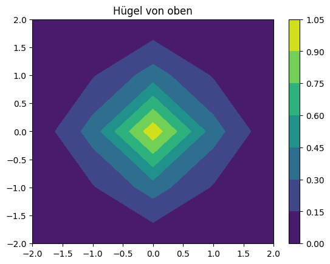

```python
import numpy as np
import matplotlib.pyplot as plt


def huegel(x, y):
    """Ein Hügel: Höhe 1 im Ursprung, fällt nach aussen ab."""
    return np.exp(-(x**2 + y**2))


# 1) Achsen: 5 Punkte von -2 bis 2
x = np.linspace(-2, 2, 5) # [-2. -1.  0.  1.  2.]
y = np.linspace(-2, 2, 5)

# 2) Gitter: alle 5 x 5 = 25 Kombinationen von x und y
X, Y = np.meshgrid(x, y)

# 3) Funktion auf allen 25 Punkten gleichzeitig auswerten
Z = huegel(X, Y)

print("X =\n", X)
print("Y =\n", Y)
print("Z =\n", np.round(Z, 2))       # Zeile i, Spalte j: Höhe am Punkt (x[j], y[i])

plt.figure()
plt.contourf(X, Y, Z)
plt.colorbar()
plt.title("Hügel von oben")

plt.show()
```

### Komplexe Zahlen

```python
z = 1 + 1j
h = -1.0j

print(z * h)
```

```
(1-1j)
```

## Matplotlib

```python
import matplotlib.pyplot as plt
import numpy as np
```

```python
f = np.exp
g = np.sin
h = np.log

x = np.linspace(0.1, 10, 500, endpoint=True) # 500 Stellen zwischen 0.1 und 10 inkl. Endpunkt
y = f(x)
```

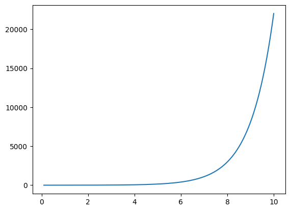

```python
plt.plot(x, y) # input 2 arrays
plt.show()
```

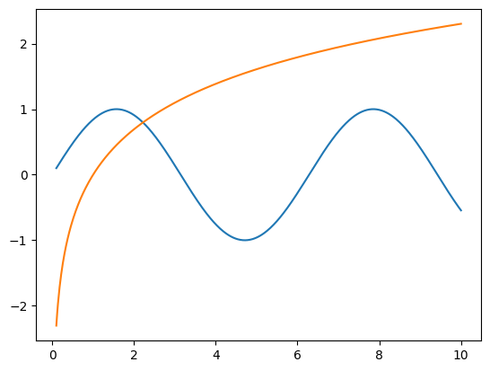

```python
plt.plot(x, g(x))
plt.plot(x, h(x))
plt.show()
```

```python
# in CodeExpert: plt.savefig("./cx_out/image.png")
```